# Firearms vs. Intentional Homicide

## The data clearly supports your opinion

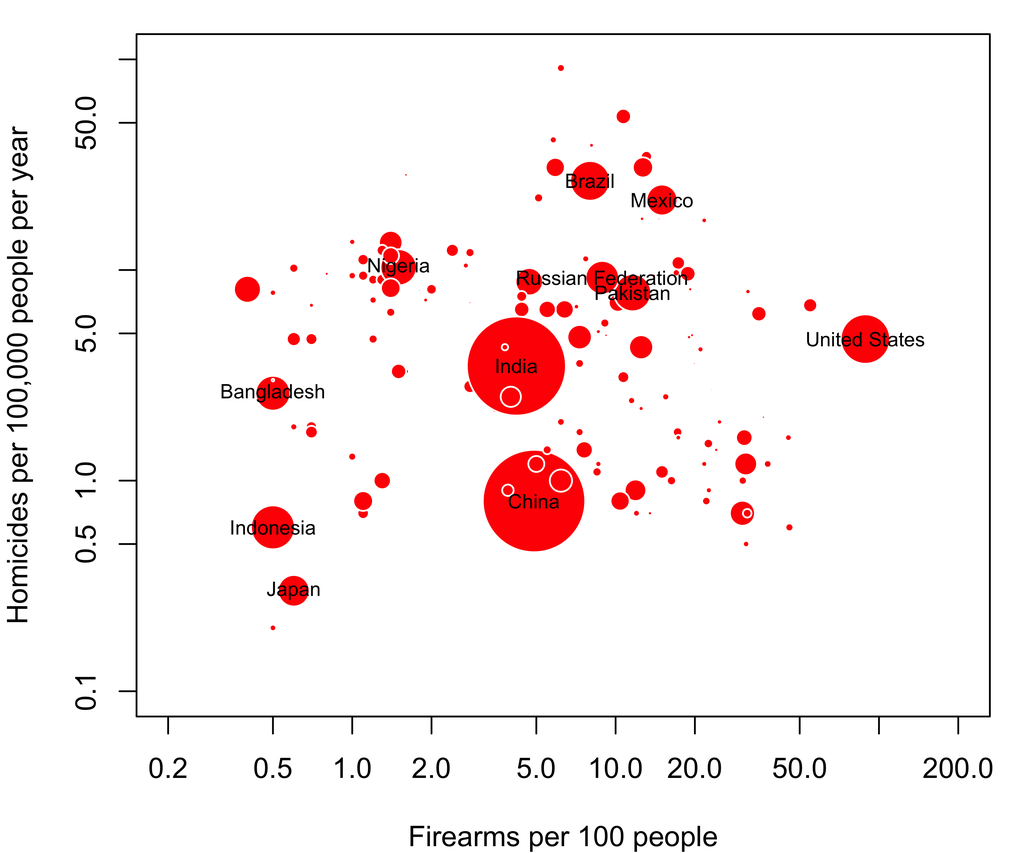

## Argument 1

Fit linear regression weighted by population.

```
Call:
lm(formula = d$homicides_per_100000 ~ d$firearms_per_100, weights = d$population)

Weighted Residuals:
    Min      1Q  Median      3Q     Max
-176815  -11915   -1625   10797  296963

Coefficients:
                   Estimate Std. Error t value Pr(>|t|)
(Intercept)        5.586611   0.777875   7.182 3.63e-11 ***
d$firearms_per_100 0.004989   0.035629   0.140    0.889
---
Signif. codes:  0 '***' 0.001 '**' 0.01 '*' 0.05 '.' 0.1 ' ' 1

Residual standard error: 54680 on 141 degrees of freedom
Multiple R-squared:  0.000139,  Adjusted R-squared:  -0.006952
F-statistic: 0.01961 on 1 and 141 DF,  p-value: 0.8888
```

Firearms are not statistically significant. Gross domestic product (at purchasing power parity) per capita can be a strong confounding variable, so fit another regression.

```
Call:
lm(formula = d$homicides_per_100000 ~ d$firearms_per_100 + d$gdp_ppp_per_capita,
    weights = d$population)

Weighted Residuals:
    Min      1Q  Median      3Q     Max
-176118   -8873   -1370   10367  301062

Coefficients:
                       Estimate Std. Error t value Pr(>|t|)
(Intercept)           6.548e+00  9.632e-01   6.798 2.82e-10 ***
d$firearms_per_100    6.500e-02  5.040e-02   1.290   0.1993
d$gdp_ppp_per_capita -1.136e-04  6.794e-05  -1.673   0.0966 .
---
Signif. codes:  0 '***' 0.001 '**' 0.01 '*' 0.05 '.' 0.1 ' ' 1

Residual standard error: 54330 on 140 degrees of freedom
Multiple R-squared:  0.01973,   Adjusted R-squared:  0.005731
F-statistic: 1.409 on 2 and 140 DF,  p-value: 0.2478
```

Even after controlling for GDP (PPP) per capita, firearms are still not statistically significant, therefore **the effect of firearms on homicide, if it exists, must be small**.

## Argument 2

Number of firearms and homicide rate are not normally distributed. Transform them by taking the log, then fit linear regression weighted by population:

```
Call:
lm(formula = log(d$homicides_per_100000) ~ log(d$firearms_per_100),
    weights = d$population)

Weighted Residuals:
   Min     1Q Median     3Q    Max
-46680  -1515   1040   3956  30481

Coefficients:
                        Estimate Std. Error t value Pr(>|t|)
(Intercept)               0.7630     0.1577   4.838  3.4e-06 ***
log(d$firearms_per_100)   0.1787     0.0795   2.248   0.0261 *
---
Signif. codes:  0 '***' 0.001 '**' 0.01 '*' 0.05 '.' 0.1 ' ' 1

Residual standard error: 7805 on 141 degrees of freedom
Multiple R-squared:  0.0346,    Adjusted R-squared:  0.02775
F-statistic: 5.053 on 1 and 141 DF,  p-value: 0.02614
```

Firearms are statistically significant and have positive coefficient in the regression, therefore **more firearms means more homicide**.

## Argument 3

Fit linear regression weighted by number of homicides. Exclude countries with gross domestic product (at purchasing power parity) per capita lower than the median because we are primarily interested in developed countries.

```
Call:
lm(formula = s$homicides_per_100000 ~ s$firearms_per_100, weights = as.numeric(s$population) *
    s$homicides_per_100000)

Weighted Residuals:
    Min      1Q  Median      3Q     Max
-580852 -120505  -62910  -33140 1155015

Coefficients:
                   Estimate Std. Error t value Pr(>|t|)
(Intercept)        27.55908    1.85457  14.860  < 2e-16 ***
s$firearms_per_100 -0.26474    0.06658  -3.976  0.00017 ***
---
Signif. codes:  0 '***' 0.001 '**' 0.01 '*' 0.05 '.' 0.1 ' ' 1

Residual standard error: 196800 on 69 degrees of freedom
Multiple R-squared:  0.1864,    Adjusted R-squared:  0.1746
F-statistic: 15.81 on 1 and 69 DF,  p-value: 0.0001701
```

Firearms are statistically significant and have negative coefficient in the regression, therefore **more firearms means less homicide**.

## Data Sources

- Intentional homicide rates per 100,000 population as of 2012, *Global Study on Homicide 2013* https://www.unodc.org/gsh/
- Total population as of 2012, *The World Bank* http://data.worldbank.org/indicator/SP.POP.TOTL
- GDP, PPP as of 2012, *The World Bank* http://data.worldbank.org/indicator/NY.GDP.MKTP.PP.CD
- Firarms per 100 population, *2007 Small Arms Survey* http://www.smallarmssurvey.org

## Data

```
                     country homicides_per_100000 population        gdp_ppp firearms_per_100
1                Afghanistan                  6.5   29726803    57473689811              4.4
2                    Albania                  5.1    2900489    27981946252              8.6
3                    Algeria                  1.4   37439427   502937371131              7.6
4                     Angola                 10.8   22685632              0             17.3
5                  Argentina                  7.0   42095224              0             10.2
6                    Armenia                  2.2    2978339    22035101326             12.5
7                  Australia                  1.1   22728254   979558023390             15.0
8                    Austria                  1.0    8429991   378088354544             30.4
9                 Azerbaijan                  2.2    9295784   150344872492              3.5
10                   Bahamas                 29.7     372388     8648379510              5.3
11                Bangladesh                  2.6  155257387   429055450182              0.5
12                  Barbados                  7.8     281580     4411222957              7.8
13                   Belarus                  3.6    9464000   162879596713              7.3
14                   Belgium                  1.7   11128246   459785570514             17.2
```

[output cut: 129 more lines]